# Agriculture within 1 km of mangrove

This notebook measures farmland sitting against mangrove that is still mapped. It does not measure mangrove that has already been cleared. The mangrove outline is held fixed, and each land-cover year is asked the same question: what share of the land within 1 km of that outline is agriculture?

The mangrove comes from Hem’s land-cover extract, `mangrove_Hem/USV_AGRUPADO`. Only the mangrove classes are kept. The same file also contains aquaculture and agriculture polygons. Those are not the habitat.

The 1 km zone is a ring outside the mangrove, cut to OHI land. A plain buffer would include the forest itself, the lagoon, and open water. Those surfaces cannot be farmland, so they are left out of both the numerator and the denominator. Where two mangrove patches sit within 2 km of each other, the rings are merged so the shared ground is counted once. The ring is then split by OHI region.

Agriculture is the INEGI land-use and vegetation inventory at 1:250,000, as distributed by CONABIO. The years are series II through VII: 2001, 2005, 2009, 2013, 2016, and 2021. Series I, the 1980–91 composite, is left out. Crop classes are every polygon whose name starts with `AGRICULTURA`. `ACUÍCOLA` is shrimp aquaculture and is left out, because that pressure is already scored as mariculture. Cultivated pasture is also left out. These maps were redrawn between series, so a change from one year to the next mixes real conversion with a new tracing of the same edge. One kilometre is about the width of that tracing uncertainty.

The pressure in a region is agricultural area inside the ring divided by the area of the ring, rounded to two decimal places. It is between 0 and 1. A region with no mangrove has no ring, so that pressure is missing.

```r
library(sf)
library(tidyverse)
library(scales)
library(knitr)

sf_use_s2(FALSE)
```

```
## Spherical geometry (s2) switched off
```

```r
knitr::opts_chunk$set(fig.width = 8, fig.height = 6, message = FALSE, warning = FALSE)

target_crs <- "EPSG:6372"

mangrove_path <- "/home/shares/ohi/OHI_GOC/_raw_data/mangrove_Hem/USV_AGRUPADO/USV_AGRUPADO.shp"
inegi_dir <- "/home/shares/ohi/OHI_GOC/_raw_data/CONABIO_Saltmarsh_landuse_veg"
rgn_path <- "/home/frazier/ohi_goc_prep/spatial/ohi_regions/goc_ohi_rgns.shp"

out_dir <- "/home/frazier/ohi_goc_prep/_pressures/prs_coastal_agriculture/output"
dir.create(out_dir, showWarnings = FALSE, recursive = TRUE)

buffer_m <- 1000

# Same four classes used for the mangrove habitat and the mariculture coastal mask.
mangrove_classes <- c(
  "MANGLAR",
  "VEGETACIÓN SECUNDARIA ARBÓREA DE MANGLAR",
  "VEGETACIÓN SECUNDARIA ARBUSTIVA DE MANGLAR",
  "VEGETACIÓN SECUNDARIA HERBÁCEA DE MANGLAR"
)

# Years are the labels in the CONABIO folder readme. Series I (1980–91) is omitted.
inegi_series <- tibble(
  year = c(2001, 2005, 2009, 2013, 2016, 2021),
  year_label = c("2001", "2005", "2009", "2013", "2016", "2021"),
  file = c(
    "usv250ks2gw/usv250ks2gw.shp",
    "usv250ks3gw/usv250ks3gw.shp",
    "usv250ks4gw/usv250ks4gw.shp",
    "usv250s5ugw/usv250s5ugw.shp",
    "usv250s6gw/usv250s6gw.shp",
    "usv250s7gw/usv250s7gw.shp"
  )
)

rgn_colors <- c(
  "Region 1" = "#C03729",
  "Region 2" = "#E68C7C",
  "Region 3" = "#FC8F24",
  "Region 4" = "#dcaa38",
  "Region 5" = "#cbd2a0",
  "Region 6" = "#98a25a",
  "Region 7" = "#747428",
  "Region 8" = "#627391",
  "Region 9" = "#8d61a9"
)

# Keep polygon pieces and drop lines created where two polygons only touch.
as_polygons <- function(x) {
  x <- st_collection_extract(st_make_valid(x), "POLYGON")
  x[!st_is_empty(x), ]
}
```

## 1. OHI regions

Each region has a land polygon and a marine polygon. The ring is cut to the land polygons. Mangrove that falls in a marine polygon still generates a ring on the land beside it.

```r
regions <- st_read(rgn_path, quiet = TRUE) %>%
  st_make_valid() %>%
  st_transform(target_crs) %>%
  mutate(
    region_label = paste("Region", as.integer(str_remove(rgn_id, "Region_")))
  )

land <- regions %>% filter(location == "land")
marine <- regions %>% filter(location == "marine")

# Geographic window used to crop the national INEGI files before transforming them.
gulf_bbox_ll <- st_bbox(st_transform(regions, 4326))
```

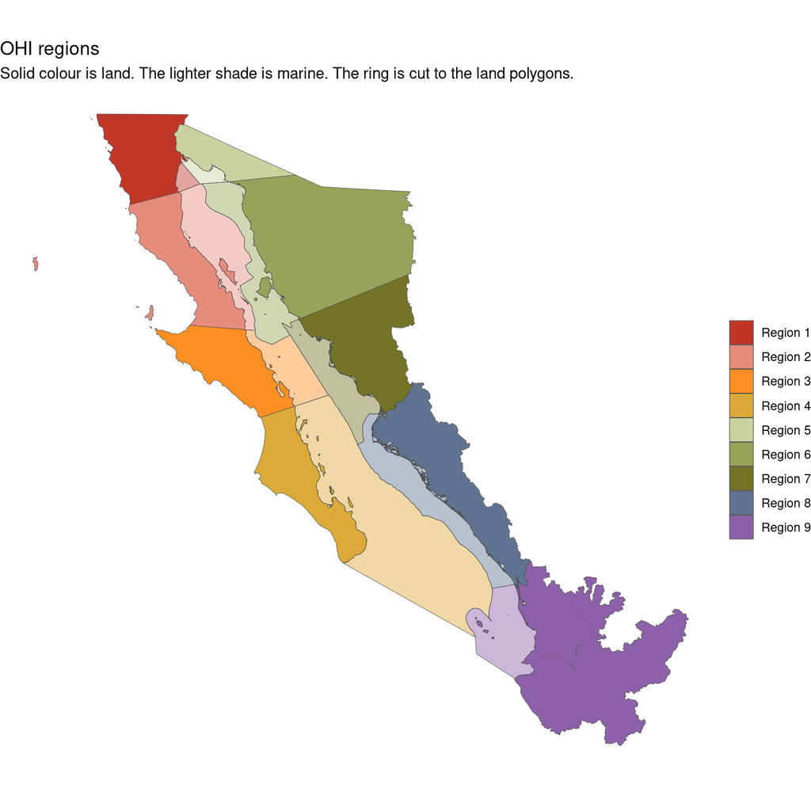

```r
ggplot() +
  geom_sf(data = land, aes(fill = region_label), color = "grey30", linewidth = 0.15) +
  geom_sf(data = marine, aes(fill = region_label), color = "grey30", linewidth = 0.15, alpha = 0.45) +
  scale_fill_manual(values = rgn_colors, name = NULL) +
  labs(
    title = "OHI regions",
    subtitle = "Solid colour is land. The lighter shade is marine. The ring is cut to the land polygons."
  ) +
  theme_void() +
  theme(legend.position = "right")
```

## 2. Mangrove outline

The outline is one map. It stays fixed while the agriculture years change. Holding it fixed means a loss of mangrove in an earlier year does not shrink the zone being measured.

```r
mangrove <- st_read(mangrove_path, quiet = TRUE) %>%
  filter(DESCRIP_AG %in% mangrove_classes) %>%
  st_transform(target_crs) %>%
  st_make_valid() %>%
  as_polygons()

stopifnot(nrow(mangrove) > 0)

# One outline, so overlapping mangrove polygons do not make a double ring.
mangrove_union <- st_union(mangrove) %>%
  st_make_valid()

mangrove_km2 <- as.numeric(st_area(mangrove_union)) / 1e6
cat("Mangrove area, km²:", round(mangrove_km2, 1), "\n")
```

```
## Mangrove area, km²: 2134.7
```

```r
cat("Mangrove polygons:", nrow(mangrove), "\n")
```

```
## Mangrove polygons: 4
```

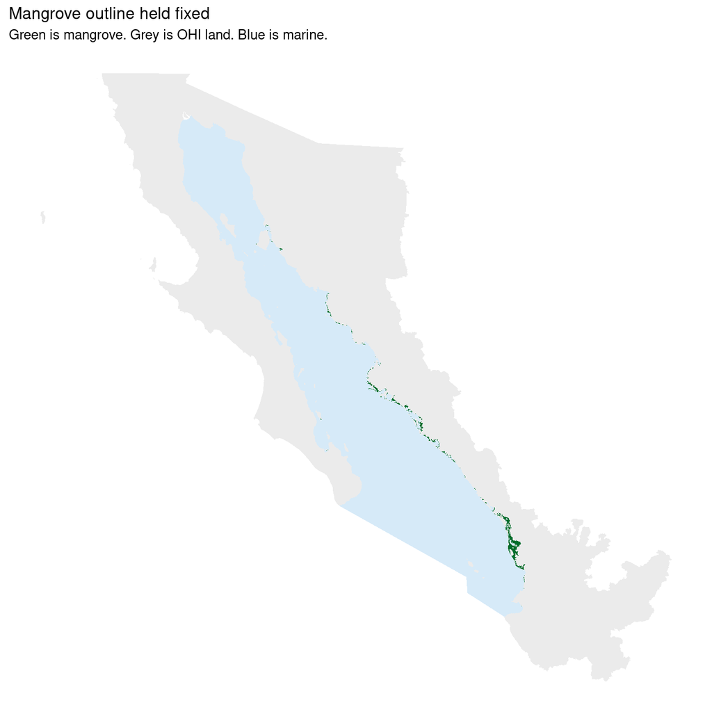

```r
ggplot() +
  geom_sf(data = land, fill = "grey92", color = NA) +
  geom_sf(data = marine, fill = "#d6eaf8", color = NA) +
  geom_sf(data = st_sf(geometry = mangrove_union), fill = "#006d2c", color = NA) +
  labs(
    title = "Mangrove outline held fixed",
    subtitle = "Green is mangrove. Grey is OHI land. Blue is marine."
  ) +
  theme_void()
```

## 3. The 1 km land ring

Buffering the outline by 1 km makes a disk that still contains the mangrove. Subtracting the mangrove leaves the ring. Intersecting that ring with the land polygons drops the water. The result is split by region, and the pieces inside one region are merged.

```r
outer <- st_buffer(mangrove_union, buffer_m)
ring_water_included <- st_difference(outer, mangrove_union) %>%
  st_make_valid() %>%
  as_polygons()

ring_by_region <- st_intersection(land, ring_water_included) %>%
  as_polygons() %>%
  group_by(rgn_id, region_label, estado, ecorgn) %>%
  summarise(geometry = st_union(geometry), .groups = "drop") %>%
  mutate(ring_km2 = as.numeric(st_area(geometry)) / 1e6) %>%
  arrange(rgn_id)

stopifnot(nrow(ring_by_region) > 0)

kable(
  st_drop_geometry(ring_by_region) %>%
    select(region_label, estado, ecorgn, ring_km2),
  digits = 1,
  col.names = c("Region", "State", "Ecoregion", "Land within 1 km, km²"),
  caption = "Area of the land ring. This is the denominator of every proportion below. Regions with no mangrove on their land are absent."
)
```

Area of the land ring. This is the denominator of every proportion below. Regions with no mangrove on their land are absent.

| Region | State | Ecoregion | Land within 1 km, km² |
| --- | --- | --- | --- |
| Region 4 | Baja_California_Sur | Southern_Gulf | 37.6 |
| Region 6 | Sonora | Midriff_Region | 75.8 |
| Region 7 | Sonora | Central_Gulf | 258.0 |
| Region 8 | Sinaloa | Southern_Gulf | 1417.7 |
| Region 9 | Nayarit | Southern_Gulf | 782.8 |

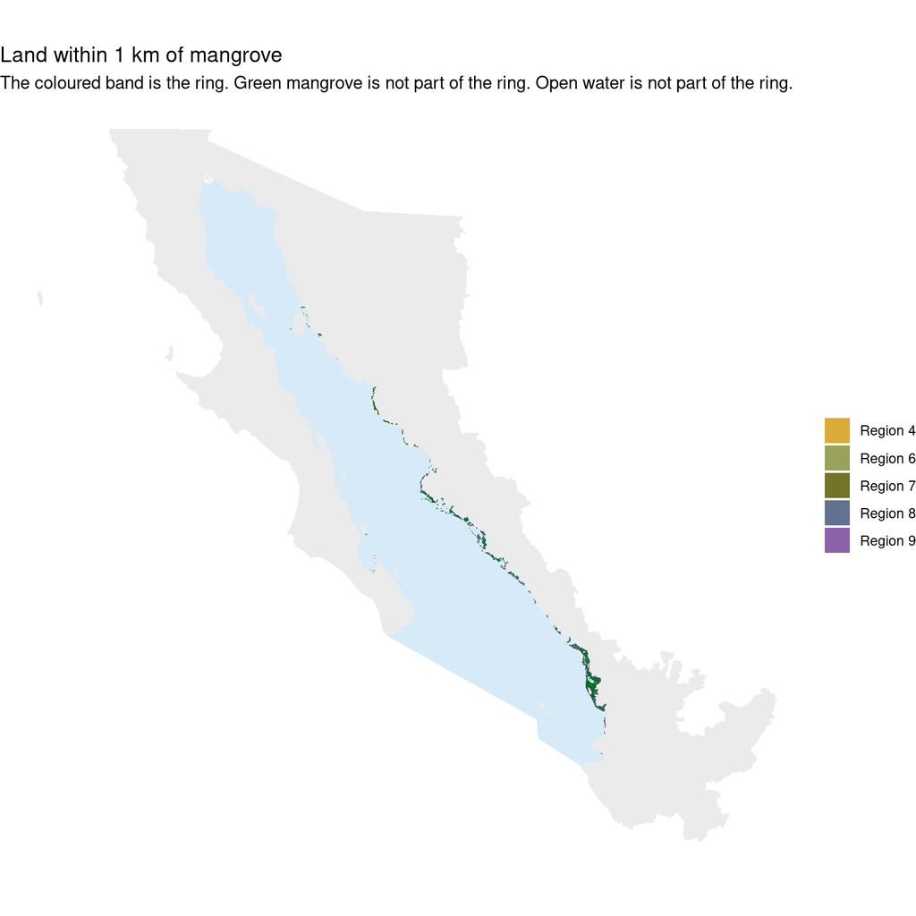

```r
ggplot() +
  geom_sf(data = land, fill = "grey92", color = NA) +
  geom_sf(data = marine, fill = "#d6eaf8", color = NA) +
  geom_sf(data = ring_by_region, aes(fill = region_label), color = NA) +
  geom_sf(data = st_sf(geometry = mangrove_union), fill = "#006d2c", color = NA) +
  scale_fill_manual(values = rgn_colors, name = NULL) +
  labs(
    title = "Land within 1 km of mangrove",
    subtitle = "The coloured band is the ring. Green mangrove is not part of the ring. Open water is not part of the ring."
  ) +
  theme_void()
```

A closer window makes the ring visible. The window is 15 km around the largest mangrove patch.

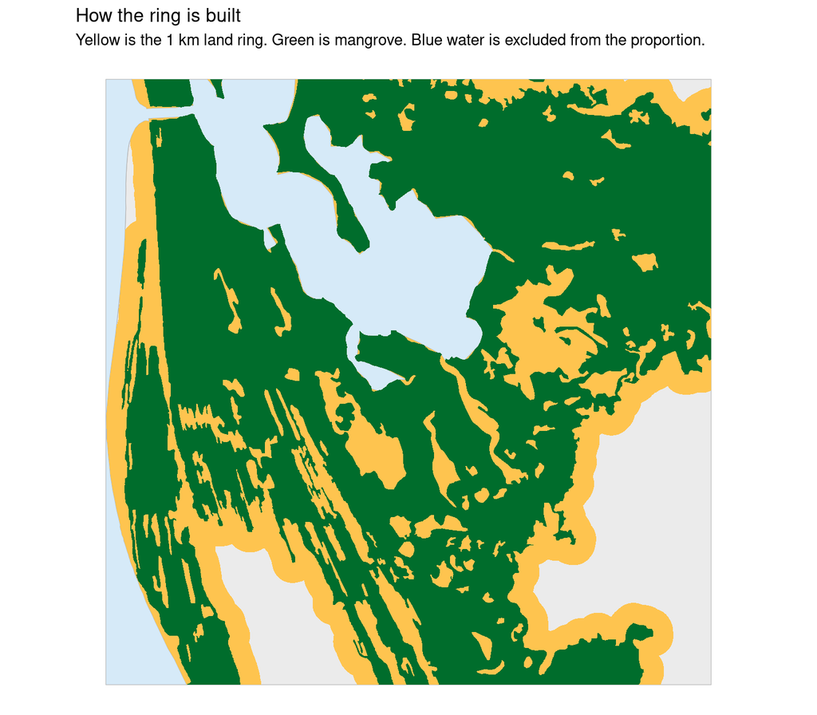

```r
pieces <- st_cast(st_sf(geometry = mangrove_union), "POLYGON")
largest <- pieces[which.max(st_area(pieces)), ]
zoom_window <- st_buffer(st_centroid(largest), 15000)

ggplot() +
  geom_sf(data = st_crop(land, zoom_window), fill = "grey92", color = "grey70", linewidth = 0.2) +
  geom_sf(data = st_crop(marine, zoom_window), fill = "#d6eaf8", color = "grey70", linewidth = 0.2) +
  geom_sf(data = st_crop(ring_by_region, zoom_window), fill = "#fec44f", color = NA) +
  geom_sf(data = st_crop(st_sf(geometry = mangrove_union), zoom_window), fill = "#006d2c", color = NA) +
  coord_sf(xlim = st_bbox(zoom_window)[c("xmin", "xmax")], ylim = st_bbox(zoom_window)[c("ymin", "ymax")]) +
  labs(
    title = "How the ring is built",
    subtitle = "Yellow is the 1 km land ring. Green is mangrove. Blue water is excluded from the proportion."
  ) +
  theme_void()
```

## 4. INEGI agriculture

Each series is a national drawing. Only polygons whose description starts with `AGRICULTURA` are read. That drops `ACUÍCOLA` and every pasture class. The polygons are cropped to the Gulf before they are projected, then intersected with the ring. Area is measured in EPSG:6372, where the unit is the metre.

```r
# Agricultural area of one INEGI series inside the ring, by region.
inegi_area_one_year <- function(year, file) {
  layer <- tools::file_path_sans_ext(basename(file))
  ag <- st_read(
    file.path(inegi_dir, file),
    query = sprintf("SELECT DESCRIPCIO FROM \"%s\" WHERE DESCRIPCIO LIKE 'AGRICULTURA%%'", layer),
    quiet = TRUE
  ) %>%
    st_make_valid() %>%
    st_crop(gulf_bbox_ll) %>%
    st_transform(target_crs) %>%
    st_make_valid()

  # Keep polygons that touch the ring, then measure the overlap.
  ag <- st_filter(ag, ring_by_region)
  if (nrow(ag) == 0) {
    return(tibble(year = integer(), rgn_id = character(), ag_km2 = double()))
  }

  st_intersection(ag, ring_by_region) %>%
    as_polygons() %>%
    mutate(
      year = year,
      ag_km2 = as.numeric(st_area(geometry)) / 1e6
    ) %>%
    st_drop_geometry() %>%
    group_by(year, rgn_id) %>%
    summarise(ag_km2 = sum(ag_km2), .groups = "drop")
}

inegi_ag <- pmap_dfr(
  inegi_series %>% select(year, file),
  inegi_area_one_year
)

inegi_prop <- ring_by_region %>%
  st_drop_geometry() %>%
  select(rgn_id, region_label, estado, ecorgn, ring_km2) %>%
  crossing(inegi_series %>% select(year, year_label)) %>%
  left_join(inegi_ag, by = c("rgn_id", "year")) %>%
  mutate(
    ag_km2 = replace_na(ag_km2, 0),
    proportion = ag_km2 / ring_km2
  )
```

```r
kable(
  inegi_prop %>%
    arrange(year, region_label) %>%
    select(year_label, region_label, ring_km2, ag_km2, proportion),
  digits = c(0, 0, 1, 1, 3),
  col.names = c("Map", "Region", "Ring, km²", "Agriculture, km²", "Proportion"),
  caption = "Share of the land ring mapped as INEGI agriculture. This share is the pressure."
)
```

Share of the land ring mapped as INEGI agriculture. This share is the pressure.

| Map | Region | Ring, km² | Agriculture, km² | Proportion |
| --- | --- | --- | --- | --- |
| 2001 | Region 4 | 37.6 | 0.0 | 0.000 |
| 2001 | Region 6 | 75.8 | 0.0 | 0.000 |
| 2001 | Region 7 | 258.0 | 1.2 | 0.004 |
| 2001 | Region 8 | 1417.7 | 202.4 | 0.143 |
| 2001 | Region 9 | 782.8 | 223.2 | 0.285 |
| 2005 | Region 4 | 37.6 | 0.4 | 0.010 |
| 2005 | Region 6 | 75.8 | 0.0 | 0.000 |
| 2005 | Region 7 | 258.0 | 3.6 | 0.014 |
| 2005 | Region 8 | 1417.7 | 220.9 | 0.156 |
| 2005 | Region 9 | 782.8 | 245.9 | 0.314 |
| 2009 | Region 4 | 37.6 | 1.4 | 0.038 |
| 2009 | Region 6 | 75.8 | 0.0 | 0.000 |
| 2009 | Region 7 | 258.0 | 3.6 | 0.014 |
| 2009 | Region 8 | 1417.7 | 247.1 | 0.174 |
| 2009 | Region 9 | 782.8 | 257.3 | 0.329 |
| 2013 | Region 4 | 37.6 | 1.4 | 0.038 |
| 2013 | Region 6 | 75.8 | 0.0 | 0.000 |
| 2013 | Region 7 | 258.0 | 3.6 | 0.014 |
| 2013 | Region 8 | 1417.7 | 254.5 | 0.180 |
| 2013 | Region 9 | 782.8 | 263.0 | 0.336 |
| 2016 | Region 4 | 37.6 | 1.4 | 0.038 |
| 2016 | Region 6 | 75.8 | 0.0 | 0.000 |
| 2016 | Region 7 | 258.0 | 3.4 | 0.013 |
| 2016 | Region 8 | 1417.7 | 259.2 | 0.183 |
| 2016 | Region 9 | 782.8 | 263.8 | 0.337 |
| 2021 | Region 4 | 37.6 | 1.4 | 0.038 |
| 2021 | Region 6 | 75.8 | 0.0 | 0.000 |
| 2021 | Region 7 | 258.0 | 3.9 | 0.015 |
| 2021 | Region 8 | 1417.7 | 259.4 | 0.183 |
| 2021 | Region 9 | 782.8 | 263.1 | 0.336 |

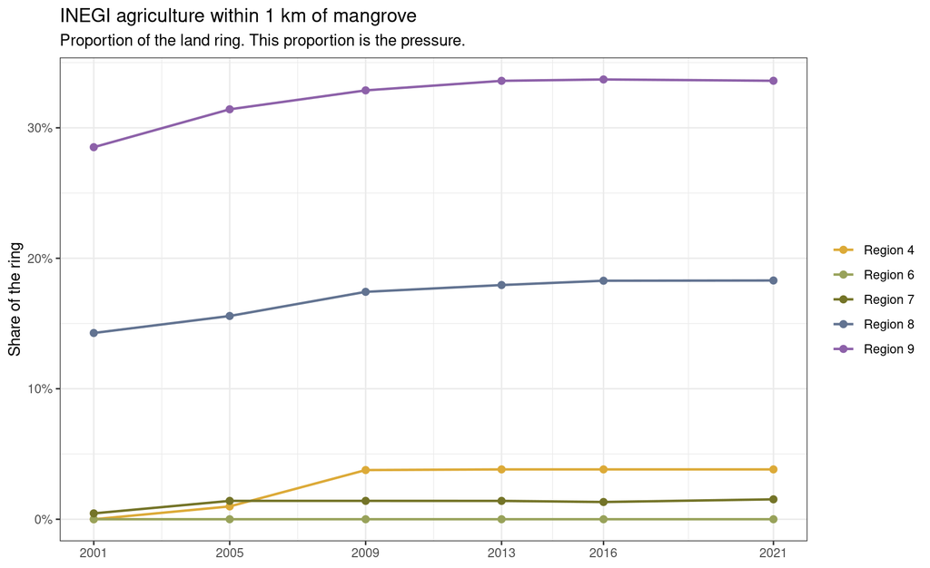

```r
ggplot(inegi_prop, aes(year, proportion, color = region_label, group = region_label)) +
  geom_line(linewidth = 0.8) +
  geom_point(size = 2) +
  scale_color_manual(values = rgn_colors, name = NULL) +
  scale_x_continuous(breaks = inegi_series$year, labels = inegi_series$year_label) +
  scale_y_continuous(labels = scales::percent_format(accuracy = 1), limits = c(0, NA)) +
  labs(
    title = "INEGI agriculture within 1 km of mangrove",
    subtitle = "Proportion of the land ring. This proportion is the pressure.",
    x = NULL,
    y = "Share of the ring"
  ) +
  theme_bw() +
  theme(legend.position = "right")
```

The 2021 map shows where that proportion comes from. Brown is INEGI agriculture inside the ring. Yellow is ring that is not agriculture.

```r
ag_2021 <- st_read(
  file.path(inegi_dir, "usv250s7gw/usv250s7gw.shp"),
  query = "SELECT DESCRIPCIO FROM \"usv250s7gw\" WHERE DESCRIPCIO LIKE 'AGRICULTURA%'",
  quiet = TRUE
) %>%
  st_make_valid() %>%
  st_crop(gulf_bbox_ll) %>%
  st_transform(target_crs) %>%
  st_make_valid() %>%
  st_filter(ring_by_region) %>%
  st_intersection(ring_by_region) %>%
  as_polygons()
```

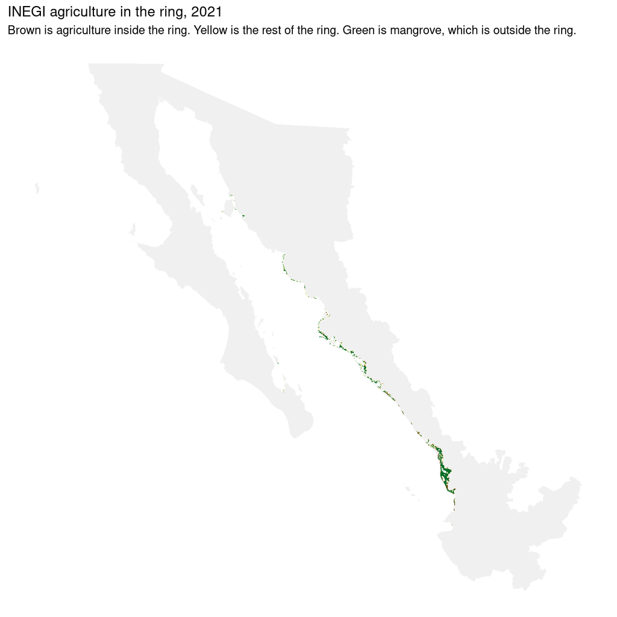

```r
ggplot() +
  geom_sf(data = land, fill = "grey94", color = NA) +
  geom_sf(data = ring_by_region, fill = "#fff7bc", color = NA) +
  geom_sf(data = ag_2021, fill = "#8c510a", color = NA) +
  geom_sf(data = st_sf(geometry = mangrove_union), fill = "#006d2c", color = NA) +
  labs(
    title = "INEGI agriculture in the ring, 2021",
    subtitle = "Brown is agriculture inside the ring. Yellow is the rest of the ring. Green is mangrove, which is outside the ring."
  ) +
  theme_void()
```

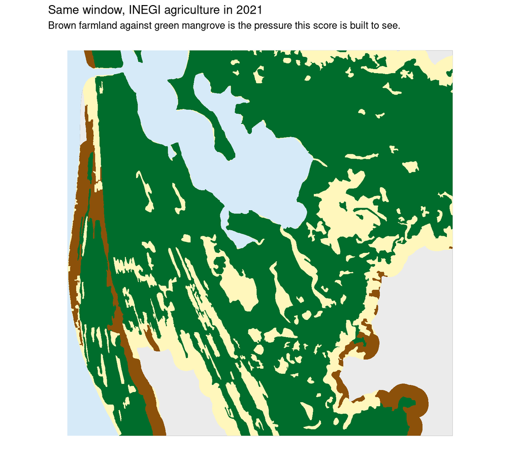

```r
ggplot() +
  geom_sf(data = st_crop(land, zoom_window), fill = "grey92", color = "grey70", linewidth = 0.15) +
  geom_sf(data = st_crop(marine, zoom_window), fill = "#d6eaf8", color = NA) +
  geom_sf(data = st_crop(ring_by_region, zoom_window), fill = "#fff7bc", color = NA) +
  geom_sf(data = st_crop(ag_2021, zoom_window), fill = "#8c510a", color = NA) +
  geom_sf(data = st_crop(st_sf(geometry = mangrove_union), zoom_window), fill = "#006d2c", color = NA) +
  coord_sf(xlim = st_bbox(zoom_window)[c("xmin", "xmax")], ylim = st_bbox(zoom_window)[c("ymin", "ymax")]) +
  labs(
    title = "Same window, INEGI agriculture in 2021",
    subtitle = "Brown farmland against green mangrove is the pressure this score is built to see."
  ) +
  theme_void()
```

Cultivated pasture is the class most easily confused with cropland. It is not in the proportion above. The 2021 area of that one class inside the ring is reported here so the exclusion has a size.

```r
pasture_2021 <- st_read(
  file.path(inegi_dir, "usv250s7gw/usv250s7gw.shp"),
  query = "SELECT DESCRIPCIO FROM \"usv250s7gw\" WHERE DESCRIPCIO = 'PASTIZAL CULTIVADO'",
  quiet = TRUE
) %>%
  st_make_valid() %>%
  st_crop(gulf_bbox_ll) %>%
  st_transform(target_crs) %>%
  st_make_valid() %>%
  st_filter(ring_by_region)

pasture_km2 <- if (nrow(pasture_2021) == 0) {
  0
} else {
  st_intersection(pasture_2021, st_union(ring_by_region)) %>%
    as_polygons() %>%
    st_area() %>%
    sum() %>%
    as.numeric() / 1e6
}

ag_2021_km2 <- sum(inegi_prop$ag_km2[inegi_prop$year == 2021])
cat("2021 agriculture inside the ring, km²:", round(ag_2021_km2, 1), "\n")
```

```
## 2021 agriculture inside the ring, km²: 527.9
```

```r
cat("2021 cultivated pasture inside the ring, km²:", round(pasture_km2, 1), "\n")
```

```
## 2021 cultivated pasture inside the ring, km²: 39.2
```

## 5. Pressure

The pressure is that proportion, rounded to two decimal places. Columns match the other pressure tables: `rgn_id`, `year`, and `pressure`. Every region is included in every year. Where the land ring has no agriculture, the pressure is 0. Where the region has no mangrove, there is no ring, and the pressure is `NA`.

```r
pressure <- land %>%
  st_drop_geometry() %>%
  distinct(rgn_id) %>%
  crossing(year = inegi_series$year) %>%
  left_join(
    inegi_prop %>% select(rgn_id, year, proportion),
    by = c("rgn_id", "year")
  ) %>%
  transmute(
    rgn_id,
    year,
    pressure = round(proportion, 2)
  ) %>%
  arrange(year, rgn_id)

stopifnot(nrow(pressure) == 9 * nrow(inegi_series))
scored <- pressure$pressure[!is.na(pressure$pressure)]
stopifnot(all(scored >= 0), all(scored <= 1))

pressure_path <- file.path(out_dir, "coastal_agriculture_pressure.csv")
write_csv(pressure, pressure_path)

kable(
  pressure,
  digits = 2,
  col.names = c("Region", "Year", "Pressure"),
  caption = "Pressure is the share of land within 1 km of mangrove that INEGI maps as agriculture. Regions with no mangrove are NA."
)
```

Pressure is the share of land within 1 km of mangrove that INEGI maps as agriculture. Regions with no mangrove are NA.

| Region | Year | Pressure |
| --- | --- | --- |
| Region_1 | 2001 | NA |
| Region_2 | 2001 | NA |
| Region_3 | 2001 | NA |
| Region_4 | 2001 | 0.00 |
| Region_5 | 2001 | NA |
| Region_6 | 2001 | 0.00 |
| Region_7 | 2001 | 0.00 |
| Region_8 | 2001 | 0.14 |
| Region_9 | 2001 | 0.29 |
| Region_1 | 2005 | NA |
| Region_2 | 2005 | NA |
| Region_3 | 2005 | NA |
| Region_4 | 2005 | 0.01 |
| Region_5 | 2005 | NA |
| Region_6 | 2005 | 0.00 |
| Region_7 | 2005 | 0.01 |
| Region_8 | 2005 | 0.16 |
| Region_9 | 2005 | 0.31 |
| Region_1 | 2009 | NA |
| Region_2 | 2009 | NA |
| Region_3 | 2009 | NA |
| Region_4 | 2009 | 0.04 |
| Region_5 | 2009 | NA |
| Region_6 | 2009 | 0.00 |
| Region_7 | 2009 | 0.01 |
| Region_8 | 2009 | 0.17 |
| Region_9 | 2009 | 0.33 |
| Region_1 | 2013 | NA |
| Region_2 | 2013 | NA |
| Region_3 | 2013 | NA |
| Region_4 | 2013 | 0.04 |
| Region_5 | 2013 | NA |
| Region_6 | 2013 | 0.00 |
| Region_7 | 2013 | 0.01 |
| Region_8 | 2013 | 0.18 |
| Region_9 | 2013 | 0.34 |
| Region_1 | 2016 | NA |
| Region_2 | 2016 | NA |
| Region_3 | 2016 | NA |
| Region_4 | 2016 | 0.04 |
| Region_5 | 2016 | NA |
| Region_6 | 2016 | 0.00 |
| Region_7 | 2016 | 0.01 |
| Region_8 | 2016 | 0.18 |
| Region_9 | 2016 | 0.34 |
| Region_1 | 2021 | NA |
| Region_2 | 2021 | NA |
| Region_3 | 2021 | NA |
| Region_4 | 2021 | 0.04 |
| Region_5 | 2021 | NA |
| Region_6 | 2021 | 0.00 |
| Region_7 | 2021 | 0.02 |
| Region_8 | 2021 | 0.18 |
| Region_9 | 2021 | 0.34 |

The pressure table is /home/frazier/ohi_goc_prep/_pressures/prs_coastal_agriculture/output/coastal_agriculture_pressure.csv.